# Friends data

This uses data from the `friends` package.

Details including the data dictionary can be found here:

https://github.com/rfordatascience/tidytuesday/issues/254

```r
# install.packages("friends")
library(tidytext)
library(tidyverse)
library(here)
library(textdata)
library(ggwordcloud)
library(lubridate)
```

## Load, join and clean data

This creates the object `friends_data`

This contains data from the original tables `friends::friends` and `friends::friends_info`

It also adds some derived fields - for example `season` and `episode` have been combined as `season_episode` (e.g. season 1, episode 1 becomes 1.01)

```r
# Add episode number for all seasons (i.e. one which does not reset to 1 at the start of a new season)
friends_info_edited <- friends::friends_info %>%
  mutate(episode_all_seasons = row_number())

# Import and join data
friends_data <- friends::friends %>%
  left_join(friends::friends_emotions, by = c("season" = "season",
                                              "episode" = "episode",
                                              "scene" = "scene",
                                              "utterance" = "utterance")
  ) %>%
#  left_join(friends::friends_entities, by = c("season" = "season",
#                                              "episode" = "episode",
#                                              "scene" = "scene",
#                                              "utterance" = "utterance")
#  ) %>%
    left_join(friends_info_edited, by = c("season" = "season",
                                            "episode" = "episode")
  ) %>%
  # Get text version of episode with leading zero for single-digit episodes
  mutate(episode_text = ifelse(nchar(episode) > 1,
                               episode,
                               str_c("0", episode, sep = "")
                        )
  ) %>%
  # Add episode text version to season to get numeric value in format "season.episode"
  mutate(season_episode =  as.numeric(str_c(season, episode_text, sep = "."))
  ) %>%
  # add episode number and title
  mutate(episode_number_name = str_c(episode_text, title, sep = " - ")) %>%

  # Get text version of scene with leading zero for single-digit scenes
  mutate(scene_text = ifelse(nchar(scene) > 1,
                               scene,
                               str_c("0", scene, sep = "")
                        )
  ) %>%

  # Get text version of episodescene
  mutate(episode_scene = str_c(episode_text, scene_text, sep = "")) %>%

  # Add episode & scene text versions to season to get numeric value in format "season.episodescene"
  mutate(season_episode_scene =  as.numeric(str_c(season, episode_scene, sep = "."))
  ) %>%

  # Get year of original transmission
  mutate(year_aired = year(air_date)) %>%

  select(-c(episode_text, scene_text, episode_scene))



# output this to a csv
write_csv(friends_data, here("clean_data/friends_data"))
```

## Unnest the text data

This creates the object `friends_words`

Note that stop words have been removed.

Scene directions have also been removed.

```r
# unnest text of utterance into words, remove stop words, add sentiment
friends_words <- friends_data %>%
  filter(speaker != "Scene Directions") %>%
  unnest_tokens(word, text) %>%
  anti_join(stop_words) %>%
  select(-emotion) %>%
  left_join(get_sentiments("bing")) %>%
  left_join(get_sentiments("afinn")) %>%
  rename("sentiment_value" = "value") %>%
  mutate(utterance_id = as.numeric(str_c(season, episode, scene, utterance, sep = "")))
```

## Create a “main characters” vector

For use in subsequent queries

```r
# Create main characters vector
main_characters <- c("Ross Geller", "Monica Geller", "Joey Tribbiani", "Chandler Bing", "Rachel Green", "Phoebe Buffay")
```

## Most common words

These are the fifty most commonly used words over the ten seasons of *Friends* (not including stop words)

The short words like “uh”, “yeah” and “gotta” should probably be excluded, but they do give quite a good indication of dialogue.

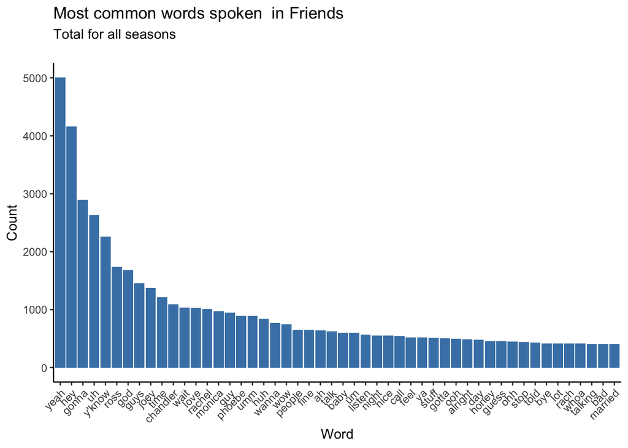

```r
friends_words %>%
  group_by(word) %>%
  summarise(count = n()) %>%
  arrange(desc(count)) %>%
  head(50) %>%
  ggplot()+
  aes(x = reorder(word, -count), y = count)+
  theme(axis.text.x = element_text(angle=45,hjust=1)) +
  theme(panel.grid.major = element_blank(), panel.grid.minor = element_blank(),
panel.background = element_blank(), axis.line = element_line(colour = "black")) +
  geom_col(fill = "steel blue") +
  labs(title = "Most common words spoken  in Friends",
       subtitle = "Total for all seasons  \n",
       x = "Word",
       y = "Count")
```

## Most common words - TF-IDF

I’ll need to look at this again - don’t think my code is working correctly

```r
friends_tf_idf <- friends_words %>%
  count(word, utterance_id) %>%
  bind_tf_idf(term = word, document = utterance_id, n = n) %>%
  arrange(desc(tf_idf))
head(friends_tf_idf)
```

```
## # A tibble: 6 x 6
##   word  utterance_id     n    tf   idf tf_idf
##   <chr>        <dbl> <int> <dbl> <dbl>  <dbl>
## 1 1250         78460     1     1  10.8   10.8
## 2 12th        106910     1     1  10.8   10.8
## 3 131         918325     1     1  10.8   10.8
## 4 1400         97315     1     1  10.8   10.8
## 5 1985        816411     1     1  10.8   10.8
## 6 1986         71214     1     1  10.8   10.8
```

## Most common sentiment words

These are the fifty most common sentiment words which were mapped to an `afinn` sentiment value.

The colour scale shows most positive words in bright green, most negative in bright red.

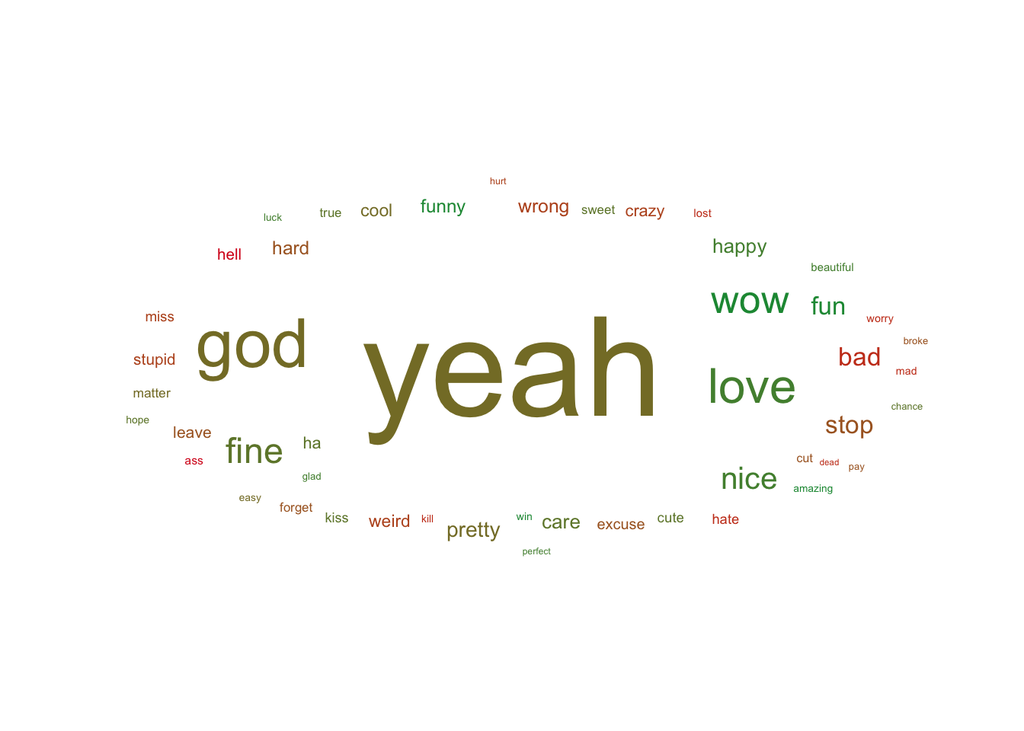

```r
friends_sentiment_words <- friends_words %>%
  filter(!is.na(sentiment_value)) %>%
  group_by(word, sentiment_value) %>%
  summarise(count = n()) %>%
  arrange(desc(count)) %>%
  head(50)


  friends_sentiment_words %>%
  ggplot()+
    aes(label= word, size = count, colour = sentiment_value) +
      geom_text_wordcloud_area() +
  scale_size_area(max_size = 24) +
  theme_minimal() +
  scale_color_gradient(low = "#d7191c", high = "#1a9641")
```

## Searches for strings

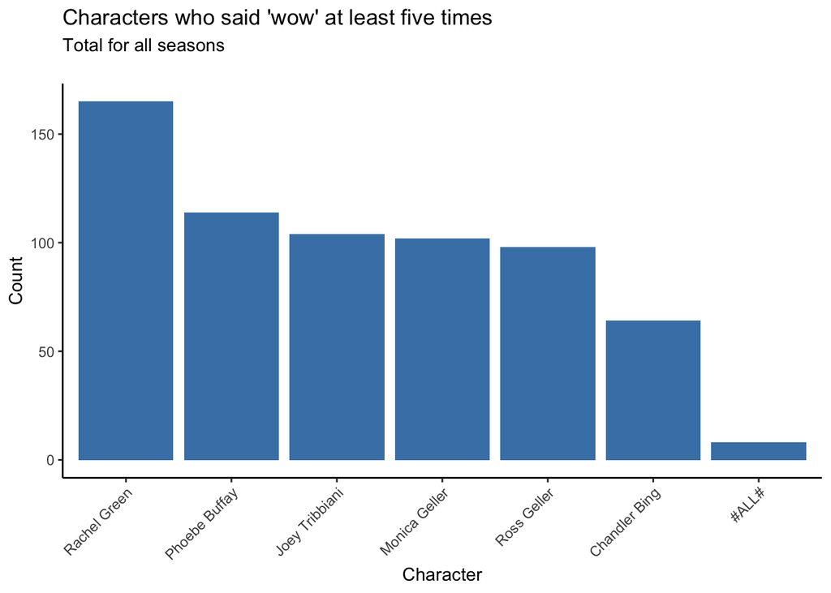

```r
friends_words %>%
  filter(word == "wow") %>%
  group_by(speaker) %>%
  summarise(count = n()) %>%
  filter(count >5) %>%
  arrange(desc(count)) %>%
  ggplot() +
  aes(x = reorder(speaker, -count), y = count) +
    theme(axis.text.x = element_text(angle=45,hjust=1)) +
  theme(panel.grid.major = element_blank(), panel.grid.minor = element_blank(),
panel.background = element_blank(), axis.line = element_line(colour = "black")) +
    geom_col(fill = "steel blue") +
  labs(title = "Characters who said 'wow' at least five times",
       subtitle = "Total for all seasons  \n",
       x = "Character",
       y = "Count")
```

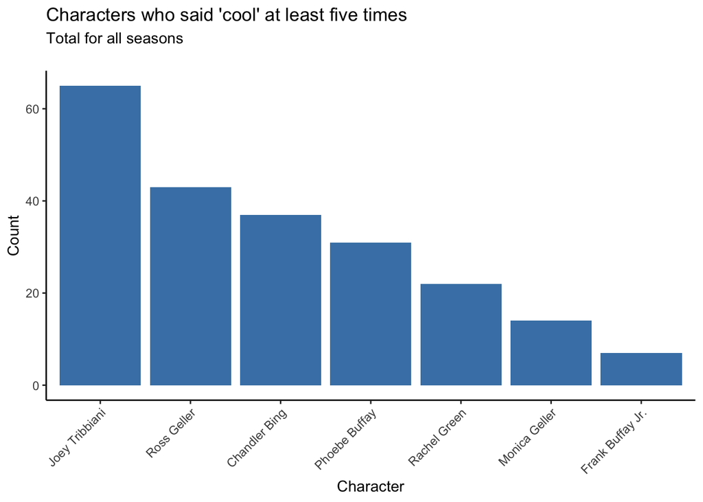

```r
friends_words %>%
  filter(word == "cool") %>%
  group_by(speaker) %>%
  summarise(count = n()) %>%
  filter(count >5) %>%
  arrange(desc(count)) %>%
  ggplot() +
  aes(x = reorder(speaker, -count), y = count) +
    theme(axis.text.x = element_text(angle=45,hjust=1)) +
  theme(panel.grid.major = element_blank(), panel.grid.minor = element_blank(),
panel.background = element_blank(), axis.line = element_line(colour = "black")) +
    geom_col(fill = "steel blue") +
  labs(title = "Characters who said 'cool' at least five times",
       subtitle = "Total for all seasons  \n",
       x = "Character",
       y = "Count")
```

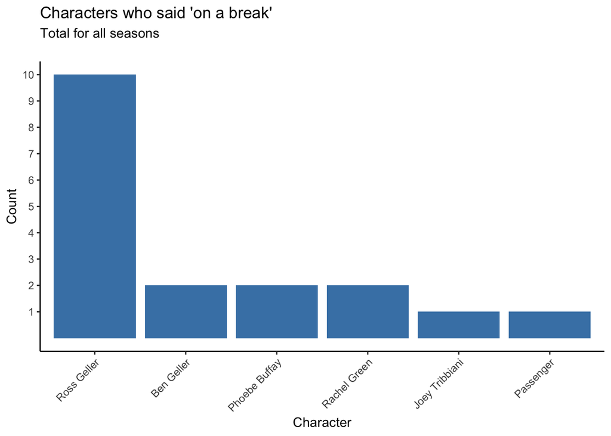

```r
friends_data %>%
  filter(str_detect(text, "[Oo][Nn] [Aa] [Bb][Rr][Ee][Aa][Kk]")) %>%
  group_by(speaker) %>%
  summarise(count = n()) %>%
  ggplot() +
  aes(x = reorder(speaker, -count), y = count) +
    theme(axis.text.x = element_text(angle=45,hjust=1)) +
  theme(panel.grid.major = element_blank(), panel.grid.minor = element_blank(),
panel.background = element_blank(), axis.line = element_line(colour = "black")) +
  scale_y_continuous(breaks = 1:10) +
    geom_col(fill = "steel blue") +
  labs(title = "Characters who said 'on a break'",
       subtitle = "Total for all seasons  \n",
       x = "Character",
       y = "Count")
```

```r
friends_data %>%
  filter(str_detect(text, "[Oo][Nn] [Aa] [Bb][Rr][Ee][Aa][Kk]")) %>%
  select(season, speaker, text)
```

```
## # A tibble: 18 x 3
##    season speaker       text
##     <int> <chr>         <chr>
##  1      3 Rachel Green  "We were on a break!"
##  2      3 Joey Tribbia… "Well, I guess he says that because they were on a brea…
##  3      3 Ross Geller   "We were on a break!!! Okay!! We were, we were..., yeah…
##  4      3 Ross Geller   "We were on a break!"
##  5      4 Ross Geller   "She wants me to take responsibility for everything tha…
##  6      4 Ross Geller   "WE WERE ON A BREAK!!!!!!!"
##  7      4 Ross Geller   "Well, if-if she thought they were on a break..."
##  8      4 Ross Geller   "WE WERE ON A BREAK!!!!!!!"
##  9      4 Passenger     "Fortunately, I won't. And by the way, it seems to be p…
## 10      5 Ross Geller   "This is fun. Hey Rach, remember that whole \"We were o…
## 11      6 Ross Geller   "What about the time I said we were on a break?"
## 12      6 Rachel Green  "Yeah. Oh I just wish we could not be married for a lit…
## 13      7 Ben Geller    "'Cause you guys were on a break."
## 14      7 Ben Geller    "That you and daddy were not on a break."
## 15      8 Phoebe Buffay "That's it?! You call that a fight? Come on! \"We were …
## 16      9 Phoebe Buffay "I dunno, well he got over the \"We were on a break\" t…
## 17      9 Ross Geller   "And that's why, no matter what mommy says, we really w…
## 18     10 Ross Geller   "This is it. Unless we're on a break."
```

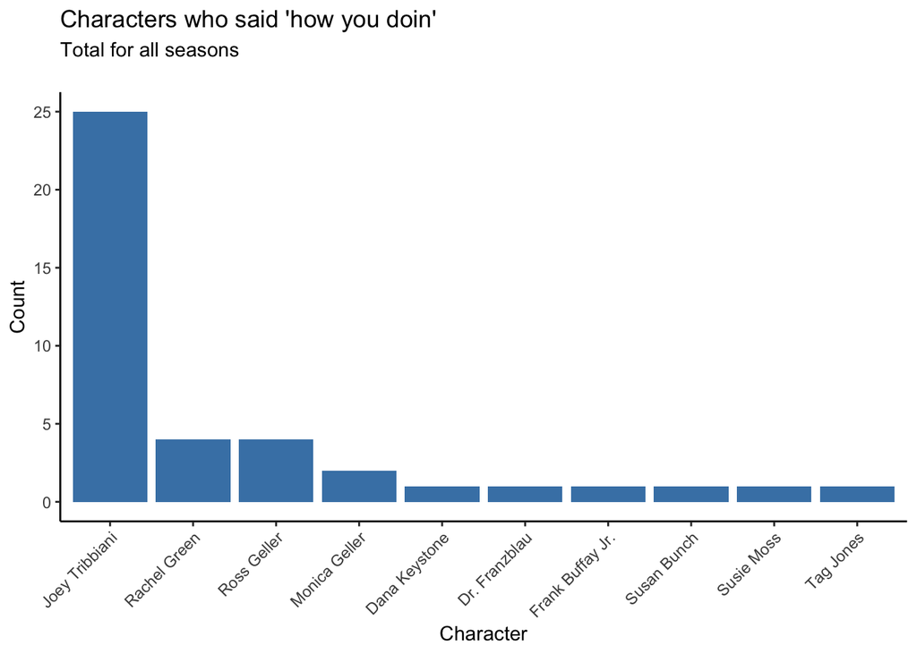

```r
friends_data %>%
  filter(str_detect(text, "[Hh][Oo][Ww] [Yy][Oo][Uu] [Dd][Oo][Ii][Nn]")) %>%
  group_by(speaker) %>%
  summarise(count = n()) %>%
  ggplot() +
  aes(x = reorder(speaker, -count), y = count) +
    theme(axis.text.x = element_text(angle=45,hjust=1)) +
  theme(panel.grid.major = element_blank(), panel.grid.minor = element_blank(),
panel.background = element_blank(), axis.line = element_line(colour = "black")) +
    geom_col(fill = "steel blue") +
  labs(title = "Characters who said 'how you doin'",
       subtitle = "Total for all seasons  \n",
       x = "Character",
       y = "Count")
```

## Mean sentiment value by episode and character

For the main characters, this looks at words which were assigned a positivity value using the `afinn` lexicon

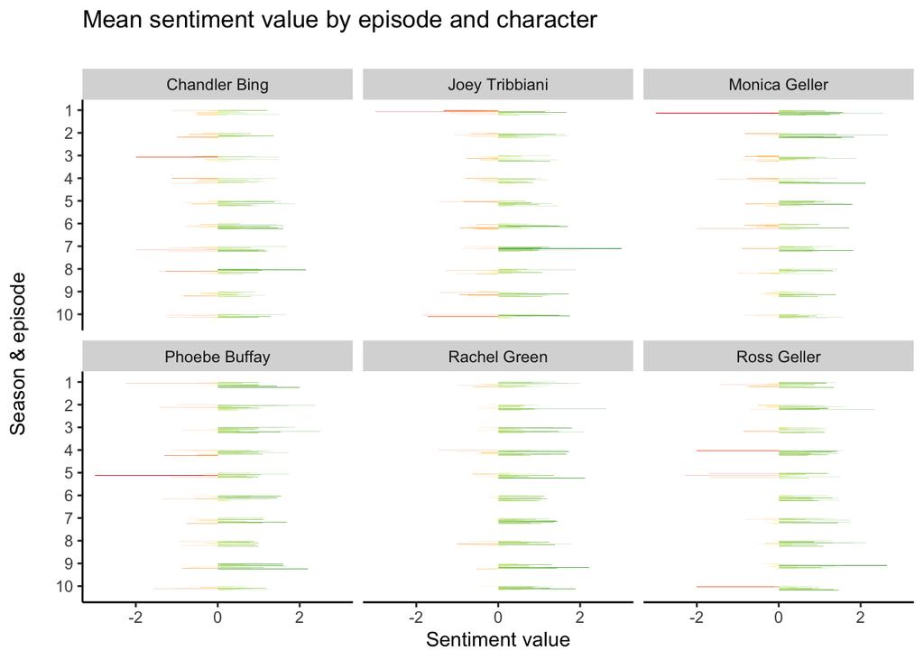

```r
friends_words %>%
  filter(speaker %in% main_characters) %>%
  filter(!is.na(sentiment_value)) %>%
  group_by(speaker, season_episode) %>%
  summarise(sentiment_value = mean(sentiment_value)) %>%
  ggplot()+
  aes(x = season_episode, y = sentiment_value, fill = sentiment_value) +
  geom_col()  +
  coord_flip() +
  theme(legend.position="") +
  theme(panel.grid.major = element_blank(), panel.grid.minor = element_blank(),
panel.background = element_blank(), axis.line = element_line(colour = "black")) +
  scale_fill_gradient2(midpoint = 0, low = "#d7191c", high = "#1a9641", mid = "#ffffbf") +
  scale_x_reverse(limits = c(10.25, 1), breaks = 1:10) +
  facet_wrap(~speaker) +
  labs(
    title = "Mean sentiment value by episode and character \n",
    x = "Season & episode \n",
    y = "Sentiment value"
  )
```

## Episodes with lowest mean sentiment value - Ross

```r
friends_words %>%
  filter(speaker == "Ross Geller") %>%
  filter(!is.na(sentiment_value)) %>%
  group_by(season_episode, title) %>%
  summarise(sentiment_value = mean(sentiment_value)) %>%
  arrange(sentiment_value) %>%
  head(5)
```

```
## # A tibble: 5 x 3
## # Groups:   season_episode [5]
##   season_episode title                         sentiment_value
##            <dbl> <chr>                                   <dbl>
## 1           5.13 The One with Joey's Bag                 -2.29
## 2           4.03 The One with the Cuffs                  -2
## 3          10.0  The One with Ross's Tan                 -2
## 4           5.05 The One with the Kips                   -1.71
## 5           5.22 The One with Joey's Big Break           -1.67
```

## Episodes with lowest mean sentiment value - Phoebe

```r
friends_words %>%
  filter(speaker == "Phoebe Buffay") %>%
  filter(!is.na(sentiment_value)) %>%
  group_by(season_episode, title) %>%
  summarise(sentiment_value = mean(sentiment_value)) %>%
  arrange(sentiment_value) %>%
  head(5)
```

```
## # A tibble: 5 x 3
## # Groups:   season_episode [5]
##   season_episode title                              sentiment_value
##            <dbl> <chr>                                        <dbl>
## 1           5.12 The One with Chandler's Work Laugh           -3
## 2           1.07 The One with the Blackout                    -2.25
## 3          10.1  The One Where Joey Speaks French             -1.57
## 4           2.13 The One After the Superbowl                  -1.42
## 5           6.16 The One That Could Have Been                 -1.36
```

## Episodes with lowest mean sentiment value - Joey

```r
friends_words %>%
  filter(speaker == "Joey Tribbiani") %>%
  filter(!is.na(sentiment_value)) %>%
  group_by(season_episode, title) %>%
  summarise(sentiment_value = mean(sentiment_value)) %>%
  arrange(sentiment_value) %>%
  head(5)
```

```
## # A tibble: 5 x 3
## # Groups:   season_episode [5]
##   season_episode title                                 sentiment_value
##            <dbl> <chr>                                           <dbl>
## 1           1.08 The One Where Nana Dies Twice                   -3
## 2          10.1  The One with Ross's Grant                       -1.83
## 3          10.1  The One Where Chandler Gets Caught              -1.73
## 4           5.05 The One with the Kips                           -1.44
## 5           9.05 The One with Phoebe's Birthday Dinner           -1.43
```

## Number of words spoken by main characters per episode

This is the total of all words (including stop words) spoken by the main characters.

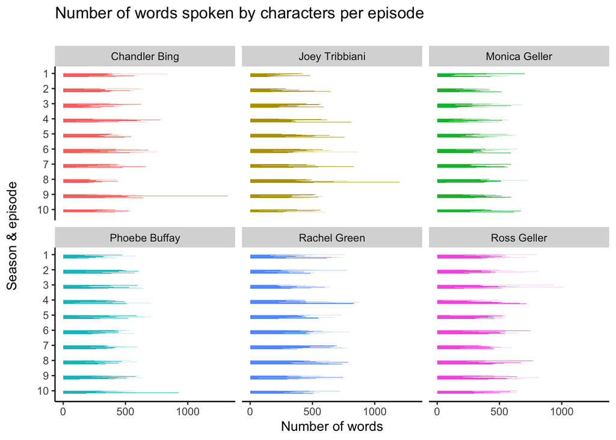

```r
# unnest text of utterance into words, remove stop words, add sentiment
friends_data %>%
  filter(speaker %in% main_characters) %>%
  unnest_tokens(word, text) %>%
  group_by(speaker, season_episode) %>%
  summarise(number_of_words = n()) %>%
ggplot() +
  aes(x = season_episode, y = number_of_words, group = speaker, fill = speaker) +
  geom_col(position = "dodge") +
  coord_flip()+
  scale_x_reverse(limits = c(10.25, 1), breaks = 1:10) +
    theme(panel.grid.major = element_blank(), panel.grid.minor = element_blank(),
panel.background = element_blank(), axis.line = element_line(colour = "black")) +
  facet_wrap(~speaker) +
  theme(legend.position = "") +
    labs(
    title = "Number of words spoken by characters per episode \n",
    x = "Season & episode \n",
    y = "Number of words"
  )
```

## Number of “negative” and “positive” words spoken by main characters

Using the `bing` classifications.

Everyone said more negative than positive.

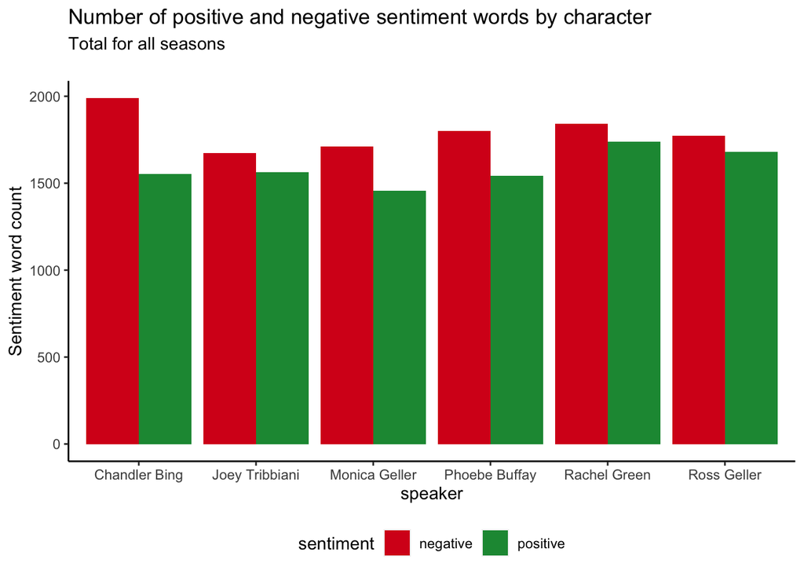

```r
friends_words %>%
  filter(speaker %in% main_characters) %>%
  filter(!is.na(sentiment)) %>%
  group_by(speaker, sentiment) %>%
  summarise(sentiment_count = n()) %>%
  ggplot()+
  aes(x = speaker, y = sentiment_count, fill = sentiment) +
  geom_col(position = "dodge")  +
  theme(legend.position="bottom") +
  theme(panel.grid.major = element_blank(), panel.grid.minor = element_blank(),
panel.background = element_blank(), axis.line = element_line(colour = "black")) +
    scale_fill_manual(
    values = c(
      "positive" = "#1a9641",
      "negative" = "#d7191c"
    )
  )+
  labs(
    title = "Number of positive and negative sentiment words by character ",
    subtitle = "Total for all seasons  \n",
    y = "Sentiment word count"
  )
```

## What do the main characters’ sentiments look like on a scene-by-scene basis?

[figure not shown]

```r
friends_words %>%
  filter(!is.na(sentiment_value)) %>%
  filter(speaker %in% main_characters) %>%
  group_by(speaker, season_episode_scene) %>%
  summarise(sentiment_value = mean(sentiment_value)) %>%
  arrange(speaker, season_episode_scene) %>%
  mutate(scene_n = row_number()) %>%
  mutate(timeline_position = scene_n/max(scene_n)) %>%

   ggplot +
    aes(x = timeline_position, y = sentiment_value, colour = speaker) +
      geom_line() +
      guides(colour = FALSE) +
      facet_wrap(~speaker, nrow = 6) +
  theme(panel.grid.major = element_blank(), panel.grid.minor = element_blank(),
panel.background = element_blank(), axis.line = element_line(colour = "black"))
```

## Mean character sentiment per season

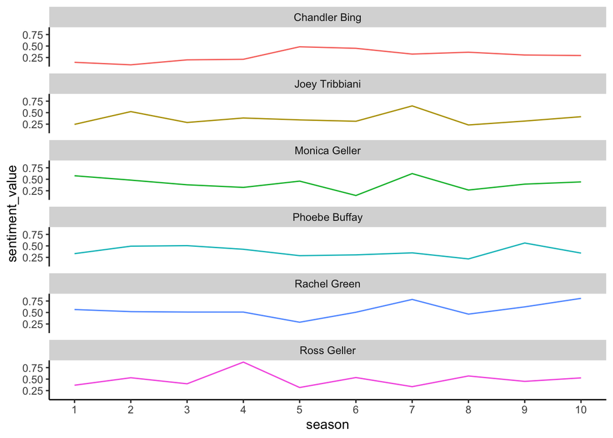

```r
friends_words %>%
  filter(!is.na(sentiment_value)) %>%
  filter(speaker %in% main_characters) %>%
  group_by(speaker, season) %>%
  summarise(sentiment_value = mean(sentiment_value)) %>%
  arrange(speaker, season) %>%


   ggplot +
    aes(x = season, y = sentiment_value, colour = speaker) +
      geom_line() +
      guides(colour = FALSE) +
      facet_wrap(~speaker, nrow = 6) +
  theme(panel.grid.major = element_blank(), panel.grid.minor = element_blank(),
panel.background = element_blank(), axis.line = element_line(colour = "black")) +
  scale_x_continuous(breaks = 1:10)
```

## It was acceptable in the 90s…

Lots of people have noted that Friends can be pretty cringy in places when you watch it now - I’m trying a few bits of analysis to see if I can highlight anything:

### Sexist language

This checks for 20 terms mentioned in this survey:

https://www.stylist.co.uk/life/sexist-feminist-special-k-strength-is-nicola-roberts-emily-blunt-hollywood-language-gender/66378

```r
# Create words vector
sexist_words <- c("hormonal",  "bitchy", "hysterical","diva", "mumsy", "princess",  "emotional", "manipulative", "bossy", "controlling", "difficult", "sexy", "aggressive", "sassy", "feisty")

# Create bigrams vector
sexist_bigrams <- c("drama queen", "high maintenance","ball breaker","highly strung","attention seeking")
```

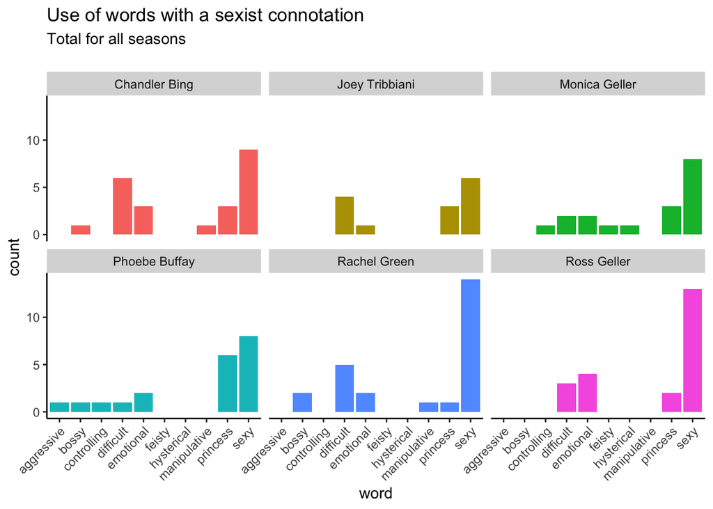

```r
# Sexist words
friends_words %>%
  filter(word %in% sexist_words) %>%
  filter(speaker %in% main_characters) %>%
  group_by(word, speaker) %>%
  summarise(count = n()) %>%
  ggplot()+
  aes(x = word, y = count, fill = speaker) +
  geom_col() +
  facet_wrap(~speaker) +
    theme(panel.grid.major = element_blank(), panel.grid.minor = element_blank(),
panel.background = element_blank(), axis.line = element_line(colour = "black")) +
  theme(axis.text.x = element_text(angle = 45, hjust=1)) +
  theme(legend.position = "") +
  labs(title = "Use of words with a sexist connotation",
       subtitle = "Total for all seasons  \n")
```

### Which writers used these words most often?

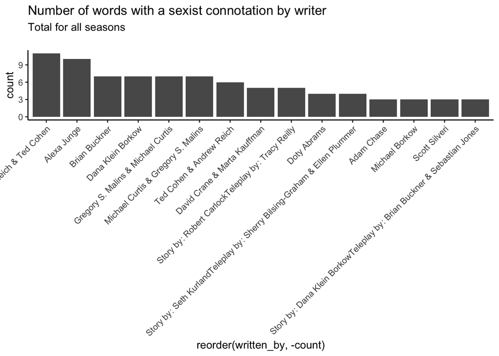

```r
# Sexist words
friends_words %>%
  filter(word %in% sexist_words) %>%
  filter(speaker != "Scene Directions") %>%
  group_by(written_by) %>%
  summarise(count = n()) %>%
  filter(count > 2) %>%
  arrange(desc(count)) %>%
  ggplot()+
  aes(x = reorder(written_by, -count), y = count) +
  geom_col() +
    theme(panel.grid.major = element_blank(), panel.grid.minor = element_blank(),
panel.background = element_blank(), axis.line = element_line(colour = "black")) +
  theme(axis.text.x = element_text(angle = 45, hjust=1)) +
  theme(legend.position = "") +
  labs(title = "Number of words with a sexist connotation by writer",
       subtitle = "Total for all seasons  \n")
```

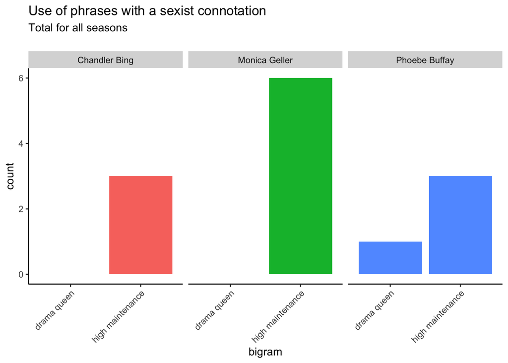

```r
# Sexist bigrams

friends_data %>%
  unnest_tokens(bigram, text, token = "ngrams", n = 2) %>%
  filter(bigram %in% sexist_bigrams) %>%
  filter(speaker %in% main_characters) %>%
  group_by(bigram, speaker) %>%
  summarise(count = n()) %>%
  ggplot()+
  aes(x = bigram, y = count, fill = speaker) +
  geom_col() +
  facet_wrap(~speaker) +
    theme(panel.grid.major = element_blank(), panel.grid.minor = element_blank(),
panel.background = element_blank(), axis.line = element_line(colour = "black")) +
  theme(axis.text.x = element_text(angle = 45, hjust=1)) +
  theme(legend.position = "") +
  labs(title = "Use of phrases with a sexist connotation",
       subtitle = "Total for all seasons  \n")
```

### Number of times a character used the word “bitch”, by year of original transmission

[figure not shown]

```r
friends_data %>%
  filter(speaker %in% main_characters) %>%
  filter(str_detect(text, "[Bb][Ii][Tt][Cc][Hh]")) %>%
  group_by(speaker, year_aired) %>%
  summarise(count = n()) %>%
  ggplot()+
  aes(x = year_aired, y = count, fill = speaker) +
  geom_col() +
  facet_wrap(~speaker) +
    theme(panel.grid.major = element_blank(), panel.grid.minor = element_blank(),
panel.background = element_blank(), axis.line = element_line(colour = "black")) +
  theme(axis.text.x = element_text(angle = 45, hjust=1)) +
  theme(legend.position = "") +
  scale_x_continuous(breaks = min(friends_data$year_aired):max(friends_data$year_aired))
```

```r
friends_data %>%
  filter(speaker == "Chandler Bing") %>%
  filter(str_detect(text, "[Bb][Ii][Tt][Cc][Hh]")) %>%
  select(text, speaker, year_aired)
```

```
## # A tibble: 11 x 3
##    text                                                   speaker     year_aired
##    <chr>                                                  <chr>            <dbl>
##  1 Yeah, well, you wouldn't think it was cool if you're … Chandler B…       1995
##  2 Crazy bitch.                                           Chandler B…       1995
##  3 Of course I am. I reject anyone who's crazy enough to… Chandler B…       1995
##  4 You bitch.                                             Chandler B…       1995
##  5 Becasue it reminded you of the way our forefathers us… Chandler B…       1996
##  6 Really, bitchin'!                                      Chandler B…       1997
##  7 No, see the thing is I want to get out of here before… Chandler B…       2000
##  8 Oh no-no-no, Monica would freak. But to hell with tha… Chandler B…       2001
##  9 That fake British woman is a real bitch, but she sure… Chandler B…       2003
## 10 Yeah! I... I... I liked it! But, ehm... my bosses did… Chandler B…       2003
## 11 Or facing a bitch of a commute.                        Chandler B…       2004
```

### Number of uses of the word “lesbian”

The “Ross and his lesbian ex wife” storyline is one of the more cringeworthy elements of the programme - examples shown below the graph.

[figure not shown]

```r
friends_data %>%
filter(speaker %in% main_characters) %>%
filter(str_detect(text, "[Ll][Ee][Ss][Bb][Ii][Aa][Nn]")) %>%
group_by(speaker, year_aired) %>%
summarise(count = n()) %>%
  ggplot()+
  aes(x = year_aired, y = count, fill = speaker) +
  geom_col() +
  facet_wrap(~speaker) +
    theme(panel.grid.major = element_blank(), panel.grid.minor = element_blank(),
panel.background = element_blank(), axis.line = element_line(colour = "black")) +
  theme(axis.text.x = element_text(angle = 45, hjust=1)) +
  theme(legend.position = "") +
  scale_x_continuous(breaks = min(friends_data$year_aired):max(friends_data$year_aired))
```

```r
friends_data %>%
filter(speaker == "Ross Geller") %>%
filter(str_detect(text, "[Ll][Ee][Ss][Bb][Ii][Aa][Nn]")) %>%
  select(text, speaker)
```

```
## # A tibble: 17 x 2
##    text                                                               speaker
##    <chr>                                                              <chr>
##  1 "Okay! Okay. Look, I, uh- I realise you guys have been wondering … Ross Gell…
##  2 "Today's the day Carol and I first.. consummated our physical rel… Ross Gell…
##  3 "It is. Eventually, it kind of... burns out. But hopefully, what … Ross Gell…
##  4 "Ooh, ooh. Because she's my ex-wife, and will probably want to br… Ross Gell…
##  5 "Ok. Wow, you guys sure have a lot of books about bein' a lesbian… Ross Gell…
##  6 "Y'see, that's where you're wrong. Why would I marry her if I tho… Ross Gell…
##  7 "Hey, I married a lesbian to make you look good!"                  Ross Gell…
##  8 "No, it's just...you know the whole \"getting on with your life\"… Ross Gell…
##  9 "No, Susans gonna be there too. Weve got dads, weve got lesbians,… Ross Gell…
## 10 "Every day is Lesbian Lover Day."                                  Ross Gell…
## 11 "It's just, it's, it's me. You, you know I've only been with one … Ross Gell…
## 12 "'Cause Carol's a lesbian. And, and I'm not one. And apparently i… Ross Gell…
## 13 "My wife's a lesbian."                                             Ross Gell…
## 14 "Actually that-that's not true, in The Incredible Hulk uh, No. 72… Ross Gell…
## 15 "Yeah, I know, so what? I mean, who's-who's to say? Does that me … Ross Gell…
## 16 "The first time! No seriously, imagine if Carol hadn't realized s… Ross Gell…
## 17 "If you have to call me name, I prefer \"Ross the Divorcer\". It'… Ross Gell…
```